# R Notebook for Replication of Li and colleagues (2014) JOHP

# Load libraries

```r
library("tidyverse")
library("olsrr")
library("descriptr")
library("haven")
library("GGally")
library("psych")
library("knitr")
library("apaTables")
library("mosaic")
library(modelr)
library(huxtable)
library(GGally)
library(car)
library(RMediation)
library(boot)
```

# Import the original datafiles

```r
# use the haven package to read in the data
#midus2 <- read_spss("04652-0001-Data.sav")

#saveRDS(midus2, "midus2.rds")
```

# Read in the saved datafiles

```r
midus2 <- readRDS("midus2.rds")
```

# Subset the datafiles

```r
# subset midus to keep only people in the main sample only
midus2.subset <- midus2 %>%
  filter ((SAMPLMAJ == 1 | SAMPLMAJ == 4) & # limit to main and metro scample
            (B1PD1 == 1 & B1PD7 == 1) & # limit to those in caregiver role
            B1PB3A == 1 & # limit to those with a superviser
            B1PB3B != 1) %>% # limit to those not self-employed
  select(M2ID,
         B1PRSEX, B1PAGE_M2, # sex and age
         B1PD10, B1PD11, B1PD12, B1PD13, B1PD14, B1PD15, # caregiver items
         B1PB12, B1PB12A, # hours worked
         B1SF27I, B1SF27J, B1SF27K, B1SF27L, # family to work conflict
         B1SJ2G, B1SJ2H, B1SJ2I, B1SJ2J, # family strain
         B1SF30C, B1SF30D, B1SF30E, # supervisor support
         B1SF1, # job satisfaction
         B1SQ1, B1PG1, B1SE1F, # life satisfaction
         B1PDEPRE) # depression
# remove cases with missing data
midus2.subset <- na.omit(midus2.subset)
describe(midus2.subset)
```

```
          vars  n     mean      sd  median  trimmed     mad
M2ID         1 62 14799.18 2844.48 15202.5 14841.44 4166.85
B1PRSEX      2 62     1.66    0.48     2.0     1.70    0.00
B1PAGE_M2    3 62    53.40    8.91    54.0    53.46    8.15
B1PD10       4 62     1.55    0.50     2.0     1.56    0.00
B1PD11       5 62     1.48    0.50     1.0     1.48    0.00
B1PD12       6 62     1.23    0.42     1.0     1.16    0.00
B1PD13       7 62     1.27    0.45     1.0     1.22    0.00
B1PD14       8 62    34.21   19.64    43.5    35.80   12.60
B1PD15       9 62    17.69   19.73    11.0    13.68   13.34
B1PB12      10 62    37.77   15.19    40.0    38.18   11.86
B1PB12A     11 62     2.03    6.57     0.0     0.44    0.00
B1SF27I     12 62     3.90    0.88     4.0     3.94    1.48
B1SF27J     13 62     3.60    0.88     4.0     3.62    1.48
B1SF27K     14 62     3.84    0.93     4.0     3.92    1.48
B1SF27L     15 62     3.92    0.80     4.0     3.94    1.48
B1SJ2G      16 62     2.39    0.69     2.0     2.46    1.48
B1SJ2H      17 62     2.79    0.85     3.0     2.84    1.48
B1SJ2I      18 62     2.85    0.81     3.0     2.90    0.00
B1SJ2J      19 62     2.56    0.80     3.0     2.56    1.48
B1SF30C     20 62     2.56    1.03     2.0     2.56    1.48
B1SF30D     21 62     2.66    1.14     3.0     2.62    1.48
B1SF30E     22 62     2.34    1.09     2.0     2.24    1.48
B1SF1       23 62     7.40    1.98     8.0     7.64    1.48
B1SQ1       24 62     7.90    1.33     8.0     8.04    1.48
B1PG1       25 62     1.55    0.76     1.0     1.40    0.00
B1SE1F      26 62     3.24    1.81     2.0     3.12    1.48
B1PDEPRE    27 62     1.18    2.24     0.0     0.72    0.00
            min   max range  skew kurtosis     se
M2ID      10186 18916  8730 -0.06    -1.53 361.25
B1PRSEX       1     2     1 -0.67    -1.58   0.06
B1PAGE_M2    34    74    40 -0.12    -0.34   1.13
B1PD10        1     2     1 -0.19    -2.00   0.06
B1PD11        1     2     1  0.06    -2.03   0.06
B1PD12        1     2     1  1.28    -0.37   0.05
B1PD13        1     2     1  0.99    -1.04   0.06
B1PD14        0    52    52 -0.44    -1.54   2.49
B1PD15        2    96    94  2.44     6.48   2.51
B1PB12        4    80    76 -0.23     0.17   1.93
B1PB12A       0    40    40  4.41    20.40   0.83
B1SF27I       1     5     4 -0.52     0.22   0.11
B1SF27J       2     5     3  0.00    -0.78   0.11
B1SF27K       2     5     3 -0.41    -0.71   0.12
B1SF27L       2     5     3 -0.24    -0.62   0.10
B1SJ2G        1     4     3 -0.35    -0.56   0.09
B1SJ2H        1     4     3 -0.38    -0.46   0.11
B1SJ2I        1     4     3 -0.48    -0.15   0.10
B1SJ2J        1     4     3 -0.02    -0.54   0.10
B1SF30C       1     5     4  0.22    -0.92   0.13
B1SF30D       1     5     4  0.29    -0.79   0.15
B1SF30E       1     5     4  0.60    -0.21   0.14
B1SF1         2    10     8 -1.04     0.43   0.25
B1SQ1         3    10     7 -1.19     2.36   0.17
B1PG1         1     4     3  1.37     1.52   0.10
B1SE1F        1     7     6  0.61    -1.01   0.23
B1PDEPRE      0     7     7  1.47     0.38   0.28
```

# Prepare variables for analysis

```r
analyze<-midus2.subset
# make all variables numeric for the dataframe we will analyze
all.vars <- names(analyze)
analyze <- analyze %>%
  mutate_at(vars(all.vars), funs(as.numeric)) # make all of these vars numeric
# rescore variables in preparation for making scale scores
analyze <- analyze %>%
  mutate(LS1 = zscore(B1SQ1),
         LS2 = zscore(B1PG1)*-1, #reverse coded
         LS3 = zscore(B1SE1F)*-1) %>% #reverse coded
  mutate(CG1 = ifelse(B1PD10 == 2, 0, B1PD10),
         CG2 = ifelse(B1PD11 == 2, 0, B1PD11),
         CG3 = ifelse(B1PD12 == 2, 0, B1PD12),
         CG4 = ifelse(B1PD13 == 2, 0, B1PD13))
#authors standardized LS items beofre combining into life satisfaction scale
analyze
```

| M2ID | B1PRSEX | B1PAGE_M2 | B1PD10 | B1PD11 | B1PD12 | B1PD13 | B1PD14 | B1PD15 | B1PB12 | B1PB12A | B1SF27I | B1SF27J | B1SF27K | B1SF27L | B1SJ2G | B1SJ2H | B1SJ2I | B1SJ2J | B1SF30C | B1SF30D | B1SF30E | B1SF1 | B1SQ1 | B1PG1 | B1SE1F | B1PDEPRE | LS1 | LS2 | LS3 | … |
| --- | --- | --- | --- | --- | --- | --- | --- | --- | --- | --- | --- | --- | --- | --- | --- | --- | --- | --- | --- | --- | --- | --- | --- | --- | --- | --- | --- | --- | --- | --- |
| 10186 | 2 | 52 | 1 | 2 | 1 | 2 | 52 | 10 | 40 | 0 | 4 | 4 | 4 | 4 | 3 | 4 | 4 | 3 | 2 | 3 | 2 | 5 | 7 | 2 | 5 | 0 | -0.68064394 | -0.5932078 | -0.9724533 | … |
| 10490 | 1 | 44 | 2 | 2 | 1 | 1 | 52 | 2 | 50 | 0 | 4 | 3 | 5 | 4 | 2 | 2 | 2 | 2 | 2 | 2 | 1 | 9 | 10 | 1 | 2 | 2 | 1.58006630 | 0.7203237 | 0.6869624 | … |
| 10546 | 2 | 54 | 2 | 2 | 1 | 1 | 8 | 20 | 40 | 0 | 5 | 4 | 4 | 4 | 3 | 3 | 4 | 3 | 3 | 3 | 3 | 8 | 8 | 1 | 2 | 0 | 0.07292614 | 0.7203237 | 0.6869624 | … |
| 10666 | 1 | 62 | 1 | 1 | 1 | 1 | 42 | 20 | 40 | 5 | 5 | 5 | 5 | 5 | 4 | 4 | 4 | 4 | 2 | 2 | 2 | 8 | 8 | 1 | 2 | 0 | 0.07292614 | 0.7203237 | 0.6869624 | … |
| 10816 | 1 | 53 | 1 | 1 | 1 | 1 | 26 | 96 | 32 | 30 | 5 | 3 | 4 | 3 | 1 | 1 | 2 | 1 | 4 | 4 | 2 | 10 | 8 | 1 | 1 | 0 | 0.07292614 | 0.7203237 | 1.2401010 | … |
| 10852 | 1 | 49 | 2 | 2 | 2 | 1 | 52 | 10 | 40 | 0 | 3 | 3 | 4 | 4 | 1 | 2 | 1 | 3 | 5 | 5 | 5 | 8 | 8 | 1 | 5 | 0 | 0.07292614 | 0.7203237 | -0.9724533 | … |
| 11000 | 1 | 58 | 1 | 1 | 1 | 1 | 45 | 10 | 14 | 0 | 3 | 4 | 4 | 3 | 3 | 3 | 3 | 3 | 2 | 2 | 1 | 9 | 6 | 2 | 3 | 6 | -1.43421403 | -0.5932078 | 0.1338239 | … |
| 11338 | 2 | 56 | 2 | 2 | 1 | 2 | 52 | 7 | 30 | 0 | 3 | 4 | 3 | 3 | 3 | 3 | 3 | 3 | 2 | 3 | 2 | 5 | 8 | 1 | 2 | 0 | 0.07292614 | 0.7203237 | 0.6869624 | … |
| 11348 | 2 | 43 | 2 | 2 | 1 | 2 | 8 | 6 | 40 | 0 | 4 | 4 | 3 | 4 | 2 | 4 | 2 | 3 | 3 | 3 | 3 | 8 | 8 | 2 | 4 | 0 | 0.07292614 | -0.5932078 | -0.4193147 | … |
| 11407 | 2 | 49 | 2 | 2 | 1 | 1 | 52 | 47 | 14 | 0 | 2 | 2 | 4 | 4 | 1 | 4 | 4 | 3 | 2 | 4 | 4 | 9 | 6 | 4 | 6 | 6 | -1.43421403 | -3.2202707 | -1.5255919 | … |

[output cut: 52 more lines]

# Examine reliability of scales

## Family/Work Conflict

```r
fwc_scale <- analyze %>%
  select(B1SF27I, B1SF27J, B1SF27K, B1SF27L) %>%
  alpha()
fwc_scale
```

```
Reliability analysis
Call: alpha(x = .)

  raw_alpha std.alpha G6(smc) average_r S/N   ase mean   sd
      0.73      0.73    0.68      0.41 2.8 0.056  3.8 0.65

 lower alpha upper     95% confidence boundaries
0.62 0.73 0.84

 Reliability if an item is dropped:
        raw_alpha std.alpha G6(smc) average_r S/N alpha se
B1SF27I      0.70      0.71    0.63      0.45 2.5    0.066
B1SF27J      0.67      0.67    0.58      0.41 2.0    0.072
B1SF27K      0.68      0.68    0.60      0.42 2.2    0.071
B1SF27L      0.63      0.63    0.53      0.36 1.7    0.082

 Item statistics
         n raw.r std.r r.cor r.drop mean   sd
B1SF27I 62  0.71  0.70  0.53   0.46  3.9 0.88
B1SF27J 62  0.75  0.75  0.63   0.52  3.6 0.88
B1SF27K 62  0.75  0.74  0.59   0.51  3.8 0.93
B1SF27L 62  0.78  0.80  0.71   0.61  3.9 0.80

Non missing response frequency for each item
           1    2    3    4    5 miss
B1SF27I 0.02 0.02 0.29 0.40 0.27    0
B1SF27J 0.00 0.10 0.37 0.37 0.16    0
B1SF27K 0.00 0.10 0.23 0.42 0.26    0
B1SF27L 0.00 0.03 0.26 0.47 0.24    0
```

Our FWC as a good internal consistency because of the high chronbachs alpha of 0.73. Removing any of the items would decrease the internal relibaility of the scale and all items correlate well with one another.

## Family Strain

```r
fs_scale <- analyze %>%
  select(B1SJ2G, B1SJ2H, B1SJ2I, B1SJ2J) %>%
  alpha()
fs_scale
```

```
Reliability analysis
Call: alpha(x = .)

  raw_alpha std.alpha G6(smc) average_r S/N   ase mean  sd
      0.77      0.77    0.73      0.45 3.3 0.049  2.6 0.6

 lower alpha upper     95% confidence boundaries
0.67 0.77 0.86

 Reliability if an item is dropped:
       raw_alpha std.alpha G6(smc) average_r S/N alpha se
B1SJ2G      0.70      0.71    0.64      0.44 2.4    0.066
B1SJ2H      0.71      0.72    0.63      0.46 2.5    0.062
B1SJ2I      0.66      0.67    0.59      0.40 2.0    0.076
B1SJ2J      0.76      0.76    0.68      0.52 3.2    0.052

 Item statistics
        n raw.r std.r r.cor r.drop mean   sd
B1SJ2G 62  0.76  0.78  0.66   0.59  2.4 0.69
B1SJ2H 62  0.78  0.77  0.66   0.56  2.8 0.85
B1SJ2I 62  0.83  0.82  0.75   0.66  2.9 0.81
B1SJ2J 62  0.71  0.71  0.55   0.47  2.6 0.80

Non missing response frequency for each item
          1    2    3    4 miss
B1SJ2G 0.10 0.44 0.45 0.02    0
B1SJ2H 0.08 0.24 0.48 0.19    0
B1SJ2I 0.06 0.21 0.53 0.19    0
B1SJ2J 0.08 0.39 0.42 0.11    0
```

Our FC as a good internal consistency because of the high chronbachs alpha of 0.77. Removing any of the items would decrease the internal relibaility of the scale and all items correlate well with one another.

## Perceived Supervisor Support

```r
pss_scale <- analyze %>%
  select(B1SF30C, B1SF30D, B1SF30E) %>%
  alpha()
pss_scale
```

```
Reliability analysis
Call: alpha(x = .)

  raw_alpha std.alpha G6(smc) average_r S/N   ase mean sd
      0.94      0.94    0.92      0.84  16 0.013  2.5  1

 lower alpha upper     95% confidence boundaries
0.91 0.94 0.97

 Reliability if an item is dropped:
        raw_alpha std.alpha G6(smc) average_r  S/N alpha se
B1SF30C      0.91      0.91    0.83      0.83 10.0    0.023
B1SF30D      0.88      0.88    0.79      0.79  7.6    0.030
B1SF30E      0.94      0.95    0.90      0.90 17.7    0.014

 Item statistics
         n raw.r std.r r.cor r.drop mean  sd
B1SF30C 62  0.95  0.95  0.92   0.88  2.6 1.0
B1SF30D 62  0.96  0.96  0.95   0.91  2.7 1.1
B1SF30E 62  0.93  0.93  0.85   0.83  2.3 1.1

Non missing response frequency for each item
           1    2    3    4    5 miss
B1SF30C 0.15 0.39 0.24 0.21 0.02    0
B1SF30D 0.16 0.32 0.27 0.18 0.06    0
B1SF30E 0.24 0.35 0.27 0.08 0.05    0
```

## Life Satisfaction

```r
#
#ls_scale <- analyze %>%
#  select(B1SQ1, B1PG1, B1SE1F) %>%
#  alpha(check.keys =TRUE)
ls2_scale <- analyze %>%
  select(LS1, LS2, LS3) %>%
  alpha(check.keys =TRUE)
#ls_scale
ls2_scale
```

```
Reliability analysis
Call: alpha(x = ., check.keys = TRUE)

  raw_alpha std.alpha G6(smc) average_r S/N  ase     mean   sd
      0.73      0.73    0.65      0.47 2.7 0.06 -1.1e-16 0.81

 lower alpha upper     95% confidence boundaries
0.61 0.73 0.85

 Reliability if an item is dropped:
    raw_alpha std.alpha G6(smc) average_r S/N alpha se
LS1      0.68      0.68    0.51      0.51 2.1    0.083
LS2      0.59      0.59    0.41      0.41 1.4    0.105
LS3      0.67      0.67    0.50      0.50 2.0    0.085

 Item statistics
     n raw.r std.r r.cor r.drop     mean sd
LS1 62  0.79  0.79  0.61   0.52 -4.7e-17  1
LS2 62  0.83  0.83  0.70   0.60 -9.3e-17  1
LS3 62  0.80  0.80  0.63   0.53 -1.5e-16  1
```

Our LS as a good internal consistency because of the high chronbachs alpha of 0.73. Removing any of the items would decrease the internal relibaility of the scale and all items correlate well with one another.

# Create Scale scale scores and final dataset for analysis

```r
analyze <- analyze %>%
  rowwise() %>%
  mutate(CGIV = sum(CG1, CG2, CG3, CG4)) %>%
  mutate(HRSWRK = ifelse(is.na(B1PB12), B1PB12, B1PB12 + B1PB12A)) %>%   mutate(FWC = 6 - mean(B1SF27I, B1SF27J, B1SF27K, B1SF27L, na.omit = TRUE)) %>%
  mutate(FAMSTRN = 5 - mean(B1SJ2G, B1SJ2H, B1SJ2I, B1SJ2J, na.omit = TRUE)) %>%
  mutate(PSS = 6 - mean(B1SF30C, B1SF30D, B1SF30E, na.omit = TRUE)) %>%
  mutate(LS = mean(LS1,LS2,LS3, na.omit = TRUE))

analyze
```

| M2ID | B1PRSEX | B1PAGE_M2 | B1PD10 | B1PD11 | B1PD12 | B1PD13 | B1PD14 | B1PD15 | B1PB12 | B1PB12A | B1SF27I | B1SF27J | B1SF27K | B1SF27L | B1SJ2G | B1SJ2H | B1SJ2I | B1SJ2J | B1SF30C | B1SF30D | B1SF30E | B1SF1 | B1SQ1 | B1PG1 | B1SE1F | B1PDEPRE | LS1 | LS2 | LS3 | … |
| --- | --- | --- | --- | --- | --- | --- | --- | --- | --- | --- | --- | --- | --- | --- | --- | --- | --- | --- | --- | --- | --- | --- | --- | --- | --- | --- | --- | --- | --- | --- |
| 10186 | 2 | 52 | 1 | 2 | 1 | 2 | 52 | 10 | 40 | 0 | 4 | 4 | 4 | 4 | 3 | 4 | 4 | 3 | 2 | 3 | 2 | 5 | 7 | 2 | 5 | 0 | -0.68064394 | -0.5932078 | -0.9724533 | … |
| 10490 | 1 | 44 | 2 | 2 | 1 | 1 | 52 | 2 | 50 | 0 | 4 | 3 | 5 | 4 | 2 | 2 | 2 | 2 | 2 | 2 | 1 | 9 | 10 | 1 | 2 | 2 | 1.58006630 | 0.7203237 | 0.6869624 | … |
| 10546 | 2 | 54 | 2 | 2 | 1 | 1 | 8 | 20 | 40 | 0 | 5 | 4 | 4 | 4 | 3 | 3 | 4 | 3 | 3 | 3 | 3 | 8 | 8 | 1 | 2 | 0 | 0.07292614 | 0.7203237 | 0.6869624 | … |
| 10666 | 1 | 62 | 1 | 1 | 1 | 1 | 42 | 20 | 40 | 5 | 5 | 5 | 5 | 5 | 4 | 4 | 4 | 4 | 2 | 2 | 2 | 8 | 8 | 1 | 2 | 0 | 0.07292614 | 0.7203237 | 0.6869624 | … |
| 10816 | 1 | 53 | 1 | 1 | 1 | 1 | 26 | 96 | 32 | 30 | 5 | 3 | 4 | 3 | 1 | 1 | 2 | 1 | 4 | 4 | 2 | 10 | 8 | 1 | 1 | 0 | 0.07292614 | 0.7203237 | 1.2401010 | … |
| 10852 | 1 | 49 | 2 | 2 | 2 | 1 | 52 | 10 | 40 | 0 | 3 | 3 | 4 | 4 | 1 | 2 | 1 | 3 | 5 | 5 | 5 | 8 | 8 | 1 | 5 | 0 | 0.07292614 | 0.7203237 | -0.9724533 | … |
| 11000 | 1 | 58 | 1 | 1 | 1 | 1 | 45 | 10 | 14 | 0 | 3 | 4 | 4 | 3 | 3 | 3 | 3 | 3 | 2 | 2 | 1 | 9 | 6 | 2 | 3 | 6 | -1.43421403 | -0.5932078 | 0.1338239 | … |
| 11338 | 2 | 56 | 2 | 2 | 1 | 2 | 52 | 7 | 30 | 0 | 3 | 4 | 3 | 3 | 3 | 3 | 3 | 3 | 2 | 3 | 2 | 5 | 8 | 1 | 2 | 0 | 0.07292614 | 0.7203237 | 0.6869624 | … |
| 11348 | 2 | 43 | 2 | 2 | 1 | 2 | 8 | 6 | 40 | 0 | 4 | 4 | 3 | 4 | 2 | 4 | 2 | 3 | 3 | 3 | 3 | 8 | 8 | 2 | 4 | 0 | 0.07292614 | -0.5932078 | -0.4193147 | … |
| 11407 | 2 | 49 | 2 | 2 | 1 | 1 | 52 | 47 | 14 | 0 | 2 | 2 | 4 | 4 | 1 | 4 | 4 | 3 | 2 | 4 | 4 | 9 | 6 | 4 | 6 | 6 | -1.43421403 | -3.2202707 | -1.5255919 | … |

[output cut: 52 more lines]

# Subset analyze dataframe so that it includes only the variables

```r
analyze <- analyze %>%
  select(B1PAGE_M2,
         B1PRSEX,
         HRSWRK,
         B1PD15,
         CGIV,
         FWC,
         FAMSTRN,
         PSS,
         B1SF1,
         LS,
         B1PDEPRE
  )
```

## Descriptive statistics for analyze dataframe

```r
describe(analyze)
```

```
          vars  n  mean    sd median trimmed   mad   min   max
B1PAGE_M2    1 62 53.40  8.91  54.00   53.46  8.15 34.00 74.00
B1PRSEX      2 62  1.66  0.48   2.00    1.70  0.00  1.00  2.00
HRSWRK       3 62 39.81 16.24  40.00   40.32 14.83  4.00 80.00
B1PD15       4 62 17.69 19.73  11.00   13.68 13.34  2.00 96.00
CGIV         5 62  2.47  1.20   2.00    2.50  1.48  0.00  4.00
FWC          6 62  2.10  0.88   2.00    2.06  1.48  1.00  5.00
FAMSTRN      7 62  2.61  0.69   3.00    2.54  1.48  1.00  4.00
PSS          8 62  3.44  1.03   4.00    3.44  1.48  1.00  5.00
B1SF1        9 62  7.40  1.98   8.00    7.64  1.48  2.00 10.00
LS          10 62  0.00  1.00   0.07    0.10  1.12 -3.69  1.58
B1PDEPRE    11 62  1.18  2.24   0.00    0.72  0.00  0.00  7.00
          range  skew kurtosis   se
B1PAGE_M2 40.00 -0.12    -0.34 1.13
B1PRSEX    1.00 -0.67    -1.58 0.06
HRSWRK    76.00 -0.22    -0.02 2.06
B1PD15    94.00  2.44     6.48 2.51
CGIV       4.00 -0.09    -1.19 0.15
FWC        4.00  0.52     0.22 0.11
FAMSTRN    3.00  0.35    -0.56 0.09
PSS        4.00 -0.22    -0.92 0.13
B1SF1      8.00 -1.04     0.43 0.25
LS         5.27 -1.19     2.36 0.13
B1PDEPRE   7.00  1.47     0.38 0.28
```

# 8. Use the apa.cor.table() function in the apaTables package to create a correlation matrix for all of the variables in the analyze dataframe.

```r
apa.cor.table(analyze, filename= "Licorr.doc",
              table.number = 1, show.conf.interval = FALSE)
```

```
The ability to suppress reporting of reporting confidence intervals has been deprecated in this version.
The function argument show.conf.interval will be removed in a later version.


Table 1

Means, standard deviations, and correlations with confidence intervals


  Variable     M     SD    1            2
  1. B1PAGE_M2 53.40 8.91

  2. B1PRSEX   1.66  0.48  -.11
                           [-.35, .14]

  3. HRSWRK    39.81 16.24 -.27*        -.25
                           [-.49, -.02] [-.47, .00]

  4. B1PD15    17.69 19.73 -.28*        .04
                           [-.49, -.03] [-.21, .28]

  5. CGIV      2.47  1.20  -.18         -.01
                           [-.41, .07]  [-.25, .24]

  6. FWC       2.10  0.88  -.00         -.04
                           [-.25, .25]  [-.28, .21]

  7. FAMSTRN   2.61  0.69  -.15         .04
                           [-.39, .10]  [-.21, .29]

  8. PSS       3.44  1.03  .16          -.03
                           [-.10, .39]  [-.28, .22]

  9. B1SF1     7.40  1.98  .19          -.23
                           [-.06, .42]  [-.46, .02]

  10. LS       -0.00 1.00  .22          -.18
                           [-.03, .44]  [-.41, .07]

  11. B1PDEPRE 1.18  2.24  -.18         .18
```

[output cut: 59 more lines]

```
  .09          .13
  [-.16, .33]  [-.12, .37]

  -.01         .28*        .33**
  [-.26, .24]  [.03, .50]  [.08, .53]

  .16          -.03        -.24        -.17
  [-.09, .40]  [-.28, .22] [-.46, .01] [-.40, .08]


Note. M and SD are used to represent mean and standard deviation, respectively.
Values in square brackets indicate the 95% confidence interval.
The confidence interval is a plausible range of population correlations
that could have caused the sample correlation (Cumming, 2014).
* indicates p < .05. ** indicates p < .01.
```

# Scatterplot of key variables

[output not shown]

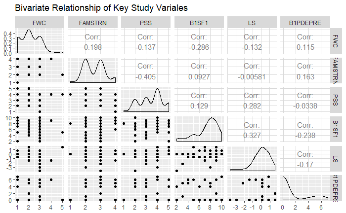

```r
library("GGally")
ggpairs(analyze, columns = c("FWC", "FAMSTRN", "PSS", "B1SF1", "LS", "B1PDEPRE"),
          title = "Bivariate Relationship of Key Study Variales")
```

# Create mean-centered variables:

```r
analyze <- analyze %>%
  mutate(B1PAGE_M2.C = B1PAGE_M2 - mean(analyze$B1PAGE_M2),
         B1PRSEX.C = B1PRSEX - mean(analyze$B1PRSEX),
         HRSWRK.C = HRSWRK - mean(analyze$HRSWRK),
         B1PD15.C  = B1PD15 - mean(analyze$B1PD15),
         CGIV.C  = CGIV - mean(analyze$CGIV),
         FWC.C  = FWC - mean(analyze$FWC),
         FAMSTRN.C  = FAMSTRN - mean(analyze$FAMSTRN),
         PSS.C  = PSS - mean(analyze$PSS),
         B1SF1.C  = B1SF1 - mean(analyze$B1SF1),
         LS.C  = LS - mean(analyze$LS),
         B1PDEPRE.C  = B1PDEPRE - mean(analyze$B1PDEPRE))
describe(analyze)
```

```
            vars  n  mean    sd median trimmed   mad    min
B1PAGE_M2      1 62 53.40  8.91  54.00   53.46  8.15  34.00
B1PRSEX        2 62  1.66  0.48   2.00    1.70  0.00   1.00
HRSWRK         3 62 39.81 16.24  40.00   40.32 14.83   4.00
B1PD15         4 62 17.69 19.73  11.00   13.68 13.34   2.00
CGIV           5 62  2.47  1.20   2.00    2.50  1.48   0.00
FWC            6 62  2.10  0.88   2.00    2.06  1.48   1.00
FAMSTRN        7 62  2.61  0.69   3.00    2.54  1.48   1.00
PSS            8 62  3.44  1.03   4.00    3.44  1.48   1.00
B1SF1          9 62  7.40  1.98   8.00    7.64  1.48   2.00
LS            10 62  0.00  1.00   0.07    0.10  1.12  -3.69
B1PDEPRE      11 62  1.18  2.24   0.00    0.72  0.00   0.00
B1PAGE_M2.C   12 62  0.00  8.91   0.60    0.06  8.15 -19.40
B1PRSEX.C     13 62  0.00  0.48   0.34    0.04  0.00  -0.66
HRSWRK.C      14 62  0.00 16.24   0.19    0.51 14.83 -35.81
B1PD15.C      15 62  0.00 19.73  -6.69   -4.01 13.34 -15.69
CGIV.C        16 62  0.00  1.20  -0.47    0.03  1.48  -2.47
FWC.C         17 62  0.00  0.88  -0.10   -0.04  1.48  -1.10
FAMSTRN.C     18 62  0.00  0.69   0.39   -0.07  1.48  -1.61
PSS.C         19 62  0.00  1.03   0.56    0.00  1.48  -2.44
B1SF1.C       20 62  0.00  1.98   0.60    0.24  1.48  -5.40
LS.C          21 62  0.00  1.00   0.07    0.10  1.12  -3.69
B1PDEPRE.C    22 62  0.00  2.24  -1.18   -0.46  0.00  -1.18
              max range  skew kurtosis   se
B1PAGE_M2   74.00 40.00 -0.12    -0.34 1.13
B1PRSEX      2.00  1.00 -0.67    -1.58 0.06
HRSWRK      80.00 76.00 -0.22    -0.02 2.06
B1PD15      96.00 94.00  2.44     6.48 2.51
CGIV         4.00  4.00 -0.09    -1.19 0.15
FWC          5.00  4.00  0.52     0.22 0.11
FAMSTRN      4.00  3.00  0.35    -0.56 0.09
PSS          5.00  4.00 -0.22    -0.92 0.13
B1SF1       10.00  8.00 -1.04     0.43 0.25
LS           1.58  5.27 -1.19     2.36 0.13
B1PDEPRE     7.00  7.00  1.47     0.38 0.28
B1PAGE_M2.C 20.60 40.00 -0.12    -0.34 1.13
B1PRSEX.C    0.34  1.00 -0.67    -1.58 0.06
HRSWRK.C    40.19 76.00 -0.22    -0.02 2.06
B1PD15.C    78.31 94.00  2.44     6.48 2.51
CGIV.C       1.53  4.00 -0.09    -1.19 0.15
FWC.C        2.90  4.00  0.52     0.22 0.11
FAMSTRN.C    1.39  3.00  0.35    -0.56 0.09
PSS.C        1.56  4.00 -0.22    -0.92 0.13
B1SF1.C      2.60  8.00 -1.04     0.43 0.25
LS.C         1.58  5.27 -1.19     2.36 0.13
B1PDEPRE.C   5.82  7.00  1.47     0.38 0.28
```

# Mediation Analyses

## Introduction

**Hypothesis**: FWC will mediate the relationship between caregiving demands & Life satisfaction only when strain from family is high & PSS is low after controlling for age and sex.

**outcome variable** = Life satisfaction **Predictor** = Caregiving Demands **Mediator** = FWC

## Methods

We will test all of the paths associated with this hypothsis. This means, testing 1.) Life satsifaction on Carigiving demans (C), 2.) FWC on CareGiving Demands (A) 3.) Life satisfaction on Caregiving Demands (B) and 4.) Life satisfaction on Caregiving demands after controlling for FWC (C’).

## Results

```r
analyze <- analyze %>%
  filter(PSS.C < 0 & FAMSTRN.C > 0)
```

### Model.xy

```r
model.xy <- lm(LS ~ CGIV.C + B1PAGE_M2 + B1PRSEX, data=analyze)
ols_regress(model.xy)
```

```
                          Model Summary
-----------------------------------------------------------------
R                        0.344       RMSE                  1.102
R-Squared                0.118       Coef. Var          -385.446
Adj. R-Squared          -0.037       MSE                   1.215
Pred R-Squared          -0.172       MAE                   0.686
-----------------------------------------------------------------
 RMSE: Root Mean Square Error
 MSE: Mean Square Error
 MAE: Mean Absolute Error

                              ANOVA
------------------------------------------------------------------
               Sum of
              Squares        DF    Mean Square      F        Sig.
------------------------------------------------------------------
Regression      2.771         3          0.924     0.76    0.5316
Residual       20.647        17          1.215
Total          23.418        20
------------------------------------------------------------------

                                  Parameter Estimates
---------------------------------------------------------------------------------------
      model      Beta    Std. Error    Std. Beta      t        Sig      lower    upper
---------------------------------------------------------------------------------------
(Intercept)    -1.395         1.969                 -0.708    0.488    -5.550    2.760
     CGIV.C     0.012         0.240        0.013     0.051    0.960    -0.494    0.518
  B1PAGE_M2     0.039         0.034        0.273     1.119    0.278    -0.034    0.111
    B1PRSEX    -0.488         0.534       -0.209    -0.914    0.374    -1.614    0.638
---------------------------------------------------------------------------------------
```

Here we are testing the overall effect of our predictor on our outcome. (C-path). The overall effect of Caregiving on life satisfaction is 0.012 while controlling for age and sex.

### model.xm

```r
model.xm <- lm(CGIV.C ~ FWC.C + B1PAGE_M2 + B1PRSEX, data=analyze)
ols_regress(model.xm)
```

```
                          Model Summary
-----------------------------------------------------------------
R                        0.386       RMSE                  1.103
R-Squared                0.149       Coef. Var          -605.721
Adj. R-Squared          -0.001       MSE                   1.216
Pred R-Squared          -0.352       MAE                   0.790
-----------------------------------------------------------------
 RMSE: Root Mean Square Error
 MSE: Mean Square Error
 MAE: Mean Absolute Error

                              ANOVA
------------------------------------------------------------------
               Sum of
              Squares        DF    Mean Square      F        Sig.
------------------------------------------------------------------
Regression      3.619         3          1.206    0.992    0.4201
Residual       20.667        17          1.216
Total          24.286        20
------------------------------------------------------------------

                                  Parameter Estimates
---------------------------------------------------------------------------------------
      model      Beta    Std. Error    Std. Beta      t        Sig      lower    upper
---------------------------------------------------------------------------------------
(Intercept)     2.025         1.913                  1.059    0.305    -2.011    6.060
      FWC.C     0.194         0.319        0.138     0.606    0.552    -0.480    0.867
  B1PAGE_M2    -0.048         0.033       -0.335    -1.484    0.156    -0.117    0.020
    B1PRSEX     0.114         0.535        0.048     0.212    0.835    -1.016    1.243
---------------------------------------------------------------------------------------
```